# Project: Investigate TMDb movie database

- Introduction
- Data Wrangling
- Exploratory Data Analysis
- Conclusions

## Introduction

Welcome to TMDb movie database investigation! We're going to explore a valuable data set which contains data for over 10,000 movies collected from The Movie Database (TMDb), the data are going to need some cleaning and tidiness before we can start but still it's quite the find and all credit goes to Kaggle and Udacity.

There are tons of options to handle the investigation so statistically speaking I can't mess this up even if I tried (*famous last words before messing up*). I am deeply intrested in finding out what *national treasure* of an actor stared most in movies, also what about the distribution of movies genres ? the movies count of each year ? are movies getting shorter ? and finally can we find out the traits of successful movies ?

### Research Questions

- 1: Which movie star landed the leading role most ?
- 2: What is the distribution of movies genres ?
- 3: How many movies are released every year ?
- 4: How long are movies every year ?
- 5: What are the traits associated with successful movies ?

## Data Wrangling

Let's load in the data, check for cleanliness, and then trim and clean the data set for analysis. I will make sure to document my steps carefully and justify my cleaning decisions.

### General Properties

```python
# First we import all the packages needed
import pandas as pd
import numpy as np
import matplotlib.pyplot as plt
import seaborn as sns

# Use a magic word to visualize results
%matplotlib inline
```

```python
# Load the data
df = pd.read_csv('tmdb-movies.csv')

# Print first two rows to check format and columns
df.head(2)
```

|  | id | imdb_id | popularity | budget | revenue | original_title | cast | homepage | director | tagline | ... | overview | runtime | genres | production_companies | release_date | vote_count | vote_average | release_year | budget_adj | revenue_adj |
| --- | --- | --- | --- | --- | --- | --- | --- | --- | --- | --- | --- | --- | --- | --- | --- | --- | --- | --- | --- | --- | --- |
| 0 | 135397 | tt0369610 | 32.985763 | 150000000 | 1513528810 | Jurassic World | Chris Pratt\|Bryce Dallas Howard\|Irrfan Khan\|Vi... | http://www.jurassicworld.com/ | Colin Trevorrow | The park is open. | ... | Twenty-two years after the events of Jurassic ... | 124 | Action\|Adventure\|Science Fiction\|Thriller | Universal Studios\|Amblin Entertainment\|Legenda... | 6/9/15 | 5562 | 6.5 | 2015 | 1.379999e+08 | 1.392446e+09 |
| 1 | 76341 | tt1392190 | 28.419936 | 150000000 | 378436354 | Mad Max: Fury Road | Tom Hardy\|Charlize Theron\|Hugh Keays-Byrne\|Nic... | http://www.madmaxmovie.com/ | George Miller | What a Lovely Day. | ... | An apocalyptic story set in the furthest reach... | 120 | Action\|Adventure\|Science Fiction\|Thriller | Village Roadshow Pictures\|Kennedy Miller Produ... | 5/13/15 | 6185 | 7.1 | 2015 | 1.379999e+08 | 3.481613e+08 |

2 rows × 21 columns

```python
# Check for data shape, missing values and data type for each column
df.info()
df.describe()
```

```
<class 'pandas.core.frame.DataFrame'>
RangeIndex: 10866 entries, 0 to 10865
Data columns (total 21 columns):
 #   Column                Non-Null Count  Dtype
---  ------                --------------  -----
 0   id                    10866 non-null  int64
 1   imdb_id               10856 non-null  object
 2   popularity            10866 non-null  float64
 3   budget                10866 non-null  int64
 4   revenue               10866 non-null  int64
 5   original_title        10866 non-null  object
 6   cast                  10790 non-null  object
 7   homepage              2936 non-null   object
 8   director              10822 non-null  object
 9   tagline               8042 non-null   object
 10  keywords              9373 non-null   object
 11  overview              10862 non-null  object
 12  runtime               10866 non-null  int64
 13  genres                10843 non-null  object
 14  production_companies  9836 non-null   object
 15  release_date          10866 non-null  object
 16  vote_count            10866 non-null  int64
 17  vote_average          10866 non-null  float64
 18  release_year          10866 non-null  int64
 19  budget_adj            10866 non-null  float64
 20  revenue_adj           10866 non-null  float64
dtypes: float64(4), int64(6), object(11)
memory usage: 1.7+ MB
```

|  | id | popularity | budget | revenue | runtime | vote_count | vote_average | release_year | budget_adj | revenue_adj |
| --- | --- | --- | --- | --- | --- | --- | --- | --- | --- | --- |
| count | 10866.000000 | 10866.000000 | 1.086600e+04 | 1.086600e+04 | 10866.000000 | 10866.000000 | 10866.000000 | 10866.000000 | 1.086600e+04 | 1.086600e+04 |
| mean | 66064.177434 | 0.646441 | 1.462570e+07 | 3.982332e+07 | 102.070863 | 217.389748 | 5.974922 | 2001.322658 | 1.755104e+07 | 5.136436e+07 |
| std | 92130.136561 | 1.000185 | 3.091321e+07 | 1.170035e+08 | 31.381405 | 575.619058 | 0.935142 | 12.812941 | 3.430616e+07 | 1.446325e+08 |
| min | 5.000000 | 0.000065 | 0.000000e+00 | 0.000000e+00 | 0.000000 | 10.000000 | 1.500000 | 1960.000000 | 0.000000e+00 | 0.000000e+00 |
| 25% | 10596.250000 | 0.207583 | 0.000000e+00 | 0.000000e+00 | 90.000000 | 17.000000 | 5.400000 | 1995.000000 | 0.000000e+00 | 0.000000e+00 |
| 50% | 20669.000000 | 0.383856 | 0.000000e+00 | 0.000000e+00 | 99.000000 | 38.000000 | 6.000000 | 2006.000000 | 0.000000e+00 | 0.000000e+00 |
| 75% | 75610.000000 | 0.713817 | 1.500000e+07 | 2.400000e+07 | 111.000000 | 145.750000 | 6.600000 | 2011.000000 | 2.085325e+07 | 3.369710e+07 |
| max | 417859.000000 | 32.985763 | 4.250000e+08 | 2.781506e+09 | 900.000000 | 9767.000000 | 9.200000 | 2015.000000 | 4.250000e+08 | 2.827124e+09 |

```python
# Check for zero values in suspected columns
(df['budget'] == 0).sum() , (df['revenue'] == 0).sum()
```

```
(5696, 6016)
```

```python
# Check that related columns have the same zero values count
(df['budget_adj'] == 0).sum() , (df['revenue_adj'] == 0).sum()
```

```
(5696, 6016)
```

I didn't like the look of the DF description regarding 'budget' and 'revenue', they don't have NaN values so I checked for zeroes and that seems to be the problem, they make up to more than half the data set so I will deal with them later when I get to analyse their columns.

## Data Cleaning

After reviewing the structure of the data and any problems that need to be cleaned, let's start the preliminary cleaning.

```
<class 'pandas.core.frame.DataFrame'>
RangeIndex: 10866 entries, 0 to 10865
Data columns (total 15 columns):
 #   Column                Non-Null Count  Dtype
---  ------                --------------  -----
 0   popularity            10866 non-null  float64
 1   budget                10866 non-null  int64
 2   revenue               10866 non-null  int64
 3   original_title        10866 non-null  object
 4   cast                  10790 non-null  object
 5   director              10822 non-null  object
 6   runtime               10866 non-null  int64
 7   genres                10843 non-null  object
 8   production_companies  9836 non-null   object
 9   release_date          10866 non-null  object
 10  vote_count            10866 non-null  int64
 11  vote_average          10866 non-null  float64
 12  release_year          10866 non-null  int64
 13  budget_adj            10866 non-null  float64
 14  revenue_adj           10866 non-null  float64
dtypes: float64(4), int64(5), object(6)
memory usage: 1.2+ MB
```

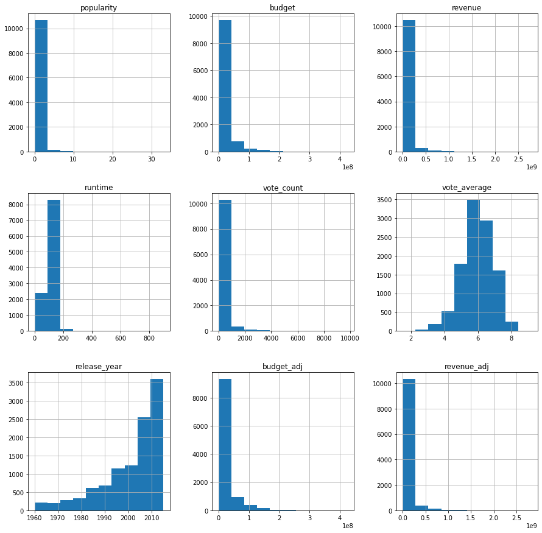

```python
# Drop unnecessary columns for starters
df.drop(['id','imdb_id','homepage','tagline','overview','keywords'], axis=1, inplace=True)

# Check columns were dropped
df.info()

# PLot histogram to see columns distribution
df.hist(figsize=(15,15));
```

It seems like the vote average column is normally distributed while the realease year column is skewed to the left, other columns are going to need some cleaning but most likely they will be skewed to the right.

```python
# Check for duplicated rows
df.duplicated().sum()
```

```
1
```

```python
# Drop duplicated rows and reset the index
df.drop_duplicates(inplace=True)
df.reset_index(drop=True, inplace=True)
```

## Exploratory Data Analysis

Now that we've trimmed and cleaned the data, we're ready to move on to exploration. Let's compute statistics and create visualizations to adress the research questions posed in the Introduction section. I will try to be systematic with my approach. Look at one variable at a time, and then follow it up by looking at relationships between variables.

### Question 1: Which movie star landed the leading role most ?

```python
# Create leads Series by picking first name in cast column
leads = df['cast'].str.split('|').str[0]

# Check result
leads
```

```
0                     Chris Pratt
1                       Tom Hardy
2                Shailene Woodley
3                   Harrison Ford
4                      Vin Diesel
                   ...
10860              Michael Hynson
10861                James Garner
10862    Innokentiy Smoktunovskiy
10863             Tatsuya Mihashi
10864            Harold P. Warren
Name: cast, Length: 10865, dtype: object
```

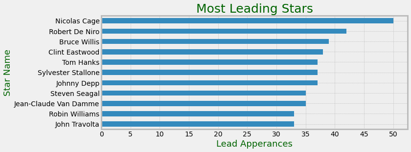

```python
# Get the top 10 leading stars
top_10 = leads.value_counts().iloc[:11]

# Plot using Matplotlib’s built-in styles
plt.style.use(['fivethirtyeight','bmh'])

# Plot using horizontal bar chart with inverted axises
top_10.plot.barh(figsize=(10,4), xticks=np.arange(0,51,5)).invert_yaxis()
plt.title('Most Leading Stars', fontsize=25, color="darkgreen")
plt.ylabel('Star Name', fontsize=18, color="darkgreen")
plt.xlabel('Lead Apperances', fontsize=18, color="darkgreen");
```

#### That's quite the record for Nicolas Cage, 50 leading roles for the 58 years old and that's excluding supporting roles!

### Question 2 : What is the distribution of movies genres ?

```python
# Replace NaN values with "Unkown|" instead of dropping rows
df['genres'].fillna('Unknown|',inplace=True)

# Split each movie genres
split_genres = df.genres.str.split('|')

# Concatenate all movies gernres into a Series
genres_series = pd.Series(np.concatenate(split_genres))

# Check result
genres_series
```

```
0                 Action
1              Adventure
2        Science Fiction
3               Thriller
4                 Action
              ...
26996            Mystery
26997             Comedy
26998             Action
26999             Comedy
27000             Horror
Length: 27001, dtype: object
```

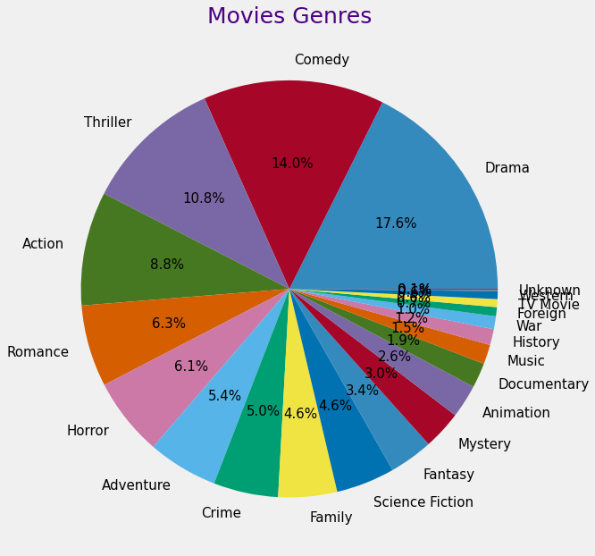

```python
# Count each genres
movies_genres = genres_series.value_counts()

# Plot a pie chart to compare genres with each other
movies_genres.plot.pie(figsize=(10,10), autopct='%1.1f%%', label="", textprops={'fontsize': 15})
plt.title('Movies Genres', fontsize=25, color="indigo");
```

#### The top 4 genres movies are more than the whole other genres combined!

### Question 3: How many movies are released every year ?

```python
# Define a function to line plot an aggregate vs years
def line_plot(style, aggregate, xticks, yticks, title, xlabel, ylabel, color):
    """ Line plot chart using matplotlib’s built-in styles

    INPUTS:
    style: matplotlib built in styles
    aggregate: the plotted aggregate grouped by release_year
    xticks: x-axis ticks
    yticks: y-axis ticks
    title: chart title
    xlabel: x-axis label
    ylabel: y-axis label
    color: labels colors

    OUTPUTS:
    Line chart with a column aggregate on the x-axis and release years on y-axis
    """
    plt.style.use(style)
    aggregate.plot(figsize=(10,5))
    plt.xticks(xticks,xticks)
    plt.yticks(yticks)
    plt.title(title, fontsize= 25, color= color)
    plt.xlabel(xlabel, fontsize= 18, color= color)
    plt.ylabel(ylabel, fontsize= 18, color= color)
    return plt.show()
```

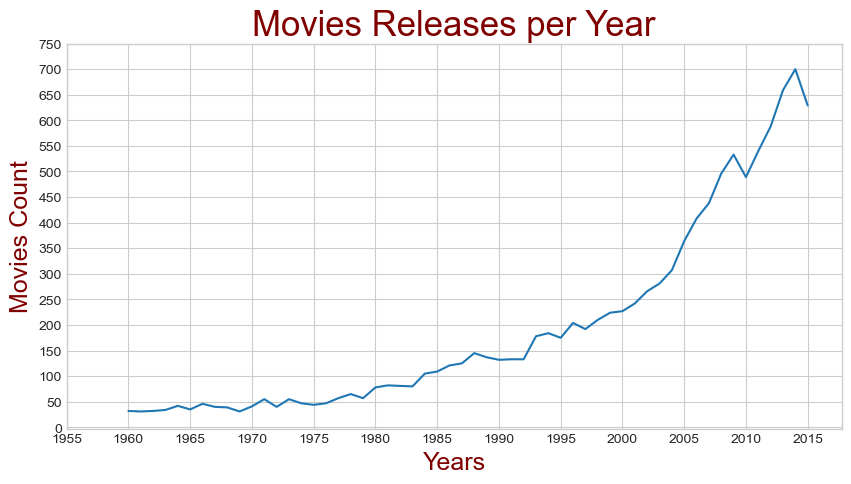

```python
# Aggregate released movies per year
yearly_releases = df.groupby('release_year')['original_title'].count()

# Reset plot style
plt.style.use('default')
# Call line plot function to plot the chart
line_plot('seaborn-whitegrid',
          yearly_releases, np.arange(1955,2016,5), np.arange(0,800,50),
          'Movies Releases per Year', 'Years', 'Movies Count','maroon')
```

#### Seems like movies count has been going steadily up untill 2000, from then the count spiked up. Is movies industry becoming more profitable and in demand lately ?

### Question 4: How long are movies every year ?

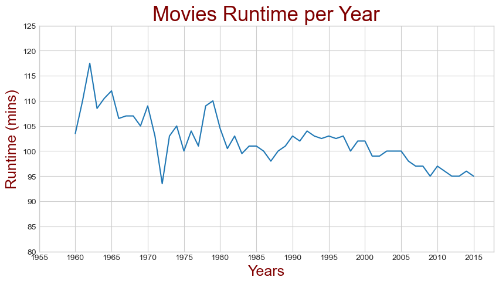

```python
# Aggregate movies average runtime for each year
yearly_runtime = df.groupby('release_year').median()['runtime']

# Line plot runtime vs years
line_plot('seaborn-whitegrid',
          yearly_runtime, np.arange(1955,2016,5), np.arange(80,130,5),
          'Movies Runtime per Year', 'Years', 'Runtime (mins)','maroon')
```

#### With our attention span getting shorter and the varied means of entertainment, it only makes sense to see runtime decreases as years go by.

### Question 5: What are the traits associated with successful movies ?

But first let's do some cleaning

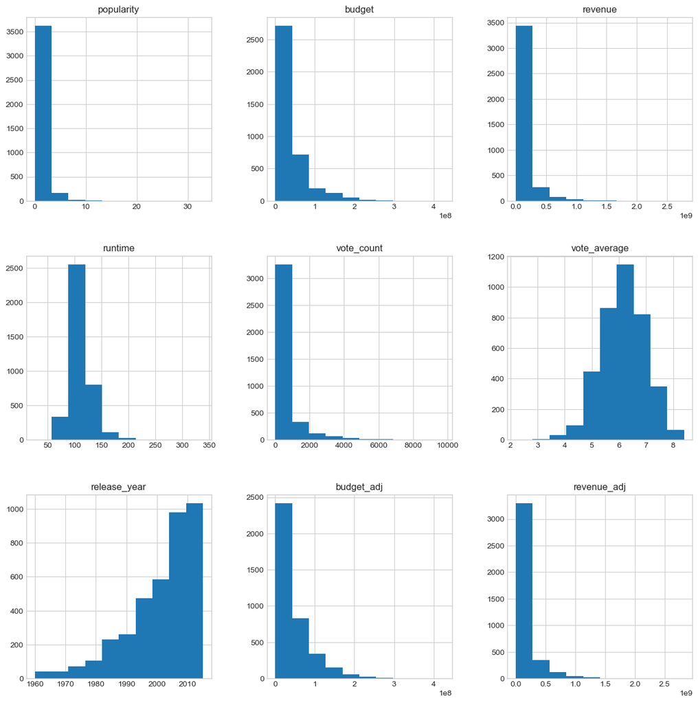

```python
# Create a DF with a min limit to minimize false entries
df_movies = df.query('revenue >= 1000 and budget >= 1000')

# Check columns disrtibution
df_movies.hist(figsize=(15,15));
```

We were right about budget, revenue and vote count having a similar distrbution as they're all skewed to the right.

```python
# Check budget and revenue statistics
df_movies.describe()
```

|  | popularity | budget | revenue | runtime | vote_count | vote_average | release_year | budget_adj | revenue_adj |
| --- | --- | --- | --- | --- | --- | --- | --- | --- | --- |
| count | 3819.000000 | 3.819000e+03 | 3.819000e+03 | 3819.000000 | 3819.000000 | 3819.000000 | 3819.000000 | 3.819000e+03 | 3.819000e+03 |
| mean | 1.198029 | 3.746202e+07 | 1.086410e+08 | 109.312385 | 531.583399 | 6.170359 | 2001.278607 | 4.454360e+07 | 1.382567e+08 |
| std | 1.480022 | 4.226268e+07 | 1.770541e+08 | 19.842850 | 882.918464 | 0.793914 | 11.297486 | 4.483451e+07 | 2.167082e+08 |
| min | 0.001117 | 6.000000e+03 | 1.938000e+03 | 26.000000 | 10.000000 | 2.200000 | 1960.000000 | 6.310011e+03 | 1.840604e+03 |
| 25% | 0.465100 | 1.000000e+07 | 1.416325e+07 | 96.000000 | 72.000000 | 5.700000 | 1995.500000 | 1.335284e+07 | 1.914479e+07 |
| 50% | 0.804481 | 2.400000e+07 | 4.589221e+07 | 106.000000 | 206.000000 | 6.200000 | 2004.000000 | 3.030653e+07 | 6.246694e+07 |
| 75% | 1.380228 | 5.000000e+07 | 1.255617e+08 | 119.000000 | 583.000000 | 6.700000 | 2010.000000 | 6.076720e+07 | 1.648478e+08 |
| max | 32.985763 | 4.250000e+08 | 2.781506e+09 | 338.000000 | 9767.000000 | 8.400000 | 2015.000000 | 4.250000e+08 | 2.827124e+09 |

```python
# Compute average profit ratio
# median is more accurate because of the outliers
(df_movies.revenue/df_movies.budget).median()
```

```
2.12607976
```

seems like the average profit is a few over 100%, so let's assume a top movie has a 300% profit

```python
# filter DF by movies with 300% profit
top_movies = df_movies.query('revenue >= 4 * budget')
top_movies.info()
```

```
<class 'pandas.core.frame.DataFrame'>
Int64Index: 1019 entries, 0 to 10827
Data columns (total 15 columns):
 #   Column                Non-Null Count  Dtype
---  ------                --------------  -----
 0   popularity            1019 non-null   float64
 1   budget                1019 non-null   int64
 2   revenue               1019 non-null   int64
 3   original_title        1019 non-null   object
 4   cast                  1018 non-null   object
 5   director              1019 non-null   object
 6   runtime               1019 non-null   int64
 7   genres                1019 non-null   object
 8   production_companies  1011 non-null   object
 9   release_date          1019 non-null   object
 10  vote_count            1019 non-null   int64
 11  vote_average          1019 non-null   float64
 12  release_year          1019 non-null   int64
 13  budget_adj            1019 non-null   float64
 14  revenue_adj           1019 non-null   float64
dtypes: float64(4), int64(5), object(6)
memory usage: 127.4+ KB
```

```python
df_movies.corr()
```

|  | popularity | budget | revenue | runtime | vote_count | vote_average | release_year | budget_adj | revenue_adj |
| --- | --- | --- | --- | --- | --- | --- | --- | --- | --- |
| popularity | 1.000000 | 0.445543 | 0.614709 | 0.214658 | 0.779619 | 0.318622 | 0.173637 | 0.397597 | 0.545945 |
| budget | 0.445543 | 1.000000 | 0.688366 | 0.261219 | 0.556013 | 0.021822 | 0.268369 | 0.958268 | 0.532575 |
| revenue | 0.614709 | 0.688366 | 1.000000 | 0.249990 | 0.754106 | 0.227215 | 0.139108 | 0.657318 | 0.900561 |
| runtime | 0.214658 | 0.261219 | 0.249990 | 1.000000 | 0.274115 | 0.356137 | -0.112308 | 0.334979 | 0.280415 |
| vote_count | 0.779619 | 0.556013 | 0.754106 | 0.274115 | 1.000000 | 0.388050 | 0.207457 | 0.496777 | 0.653978 |
| vote_average | 0.318622 | 0.021822 | 0.227215 | 0.356137 | 0.388050 | 1.000000 | -0.137063 | 0.034321 | 0.267258 |
| release_year | 0.173637 | 0.268369 | 0.139108 | -0.112308 | 0.207457 | -0.137063 | 1.000000 | 0.074192 | -0.104267 |
| budget_adj | 0.397597 | 0.958268 | 0.657318 | 0.334979 | 0.496777 | 0.034321 | 0.074192 | 1.000000 | 0.569742 |
| revenue_adj | 0.545945 | 0.532575 | 0.900561 | 0.280415 | 0.653978 | 0.267258 | -0.104267 | 0.569742 | 1.000000 |

```python
top_movies.corr()
```

|  | popularity | budget | revenue | runtime | vote_count | vote_average | release_year | budget_adj | revenue_adj |
| --- | --- | --- | --- | --- | --- | --- | --- | --- | --- |
| popularity | 1.000000 | 0.540282 | 0.635027 | 0.285732 | 0.774950 | 0.353137 | 0.228037 | 0.504078 | 0.549032 |
| budget | 0.540282 | 1.000000 | 0.872714 | 0.318929 | 0.694141 | 0.135080 | 0.343603 | 0.954378 | 0.653419 |
| revenue | 0.635027 | 0.872714 | 1.000000 | 0.345586 | 0.748435 | 0.189512 | 0.269774 | 0.846452 | 0.856068 |
| runtime | 0.285732 | 0.318929 | 0.345586 | 1.000000 | 0.372117 | 0.395108 | -0.090604 | 0.418154 | 0.403453 |
| vote_count | 0.774950 | 0.694141 | 0.748435 | 0.372117 | 1.000000 | 0.423501 | 0.293837 | 0.647560 | 0.617500 |
| vote_average | 0.353137 | 0.135080 | 0.189512 | 0.395108 | 0.423501 | 1.000000 | -0.110793 | 0.159717 | 0.246244 |
| release_year | 0.228037 | 0.343603 | 0.269774 | -0.090604 | 0.293837 | -0.110793 | 1.000000 | 0.156242 | -0.076239 |
| budget_adj | 0.504078 | 0.954378 | 0.846452 | 0.418154 | 0.647560 | 0.159717 | 0.156242 | 1.000000 | 0.733047 |
| revenue_adj | 0.549032 | 0.653419 | 0.856068 | 0.403453 | 0.617500 | 0.246244 | -0.076239 | 0.733047 | 1.000000 |

It looks like top movies have better correlation between columns

```python
# Define a function to scatter plot two columns
def scatter_plot(style, col_1, col_2, title, xlabel, ylabel, color):
    """ Scatter plot using matplotlib’s built-in styles

    INPUTS:
    style: matplotlib built in styles
    col_1: x-axis values
    col_2: y-axis values
    title: chart title
    xlabel: x-axis label
    ylabel: y-axis label
    color: labels colors

    OUTPUTS:
    Scatter plot the correlation between two columns
    """
    plt.style.use(style)
    plt.scatter(x= col_1 , y= col_2)
    plt.title(title, fontsize= 25, color= color)
    plt.xlabel(xlabel, fontsize= 18, color= color)
    plt.ylabel(ylabel, fontsize= 18, color= color)
    return plt.show()
```

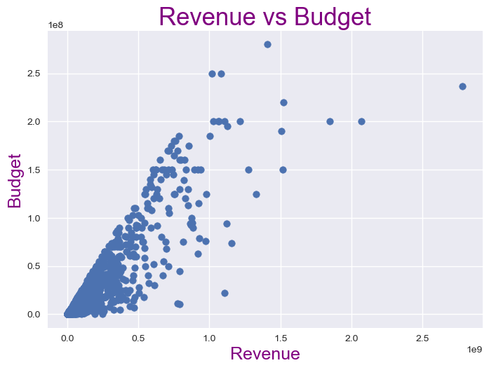

```python
# Call scatter_plot function to find correlation between revenue and budget
scatter_plot('seaborn',
             top_movies.revenue, top_movies.budget,
             'Revenue vs Budget', 'Revenue', 'Budget', 'purple')
```

looks like at the top there's a good chance that spending more slightly increases your revenue

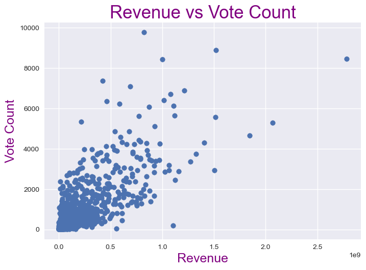

```python
# Call scatter_plot function to find correlation between revenue and vote count
scatter_plot('seaborn',
             top_movies.revenue, top_movies.vote_count,
             'Revenue vs Vote Count', 'Revenue', 'Vote Count', 'purple')
```

Seems like movies with high reveunes receive more online interaction from fans

## Conclusions

- On average a top 10 lead actor stars in 37 movies, Nicolas Cage outlies the average by 13 movies.
- The top 2 genres (31.6%) make one third of movies count while the top 4 genres (51.2%) make half.
- Movies count is on the rise since the 60s and spiked up from the 00s.
- Movies runtime slowly shortens with time.
- Top Movies with at least 300% profit have strong correlation between revenue, budget and vote count.

### Limitations

- More than half of the data contains zero values in either budget or revenue.
- Popularity column isn't properly explained and it's scale is unknown.
- Columns with names aren't well formatted.